# Grand Slams 2017. Clustering Analysis

Author

Jordi Cortés

## Executive summary

This document shows the results of a clustering analysis applied to matches of the **four Grand Slam men’s singles in year 2017**.

There are two main clustering analysis:

- Classifying **matches** according to their characteristics of workload and intensity
- Classifying **players** according to their characteristics of workload and intensity in the matches that they played

## Descriptive of the sample

### Matches

The total collected number of matches was **282** matches.

| **Characteristic** | **N = 282** <sup>1</sup> |
| --- | --- |
| surface |  |
| Clay | 42 (15%) |
| Grass | 76 (27%) |
| Hard | 164 (58%) |
| Slam |  |
| ausopen | 85 (30%) |
| frenchopen | 42 (15%) |
| usopen | 79 (28%) |
| wimbledon | 76 (27%) |

<sup>1</sup> n (%)

### Players

The total number of collected male players participated in Grand Slams during 2017 was **152**.

### Variables

The collected variables for each match were:

*match_id, RallyCount, P1Dist, P2Dist, Point, Speed, Speed1, Speed2, FirstServe1, SecondServe1, DoubleFault1, FirstServe2, SecondServe2, DoubleFault2, Time, matchnum, Slam, Gender, player1, player2, split_time, total_minutes, played_minutes, rally_min, P1dist_min, P2dist_min, Dist, Dist_min, FirstServe, SecondServe, DoubleFault, year, surface, PercFirstServe1, PercSecondServe1, PercDoubleFault1, PercFirstServe2, PercSecondServe2, PercDoubleFault2, PercFirstServe, PercSecondServe, PercDoubleFault*

The collected variables for each player were:

*Player, n, RallyCount, Dist, Point, Speed, FirstServe, SecondServe, DoubleFault, played_minutes, Gender, rally_min, rally_match, Dist_min, Dist_match, Point_min, Point_match, played_minutes_match, PercFirstServe, PercSecondServe, PercDoubleFault*

## Clustering of matches

### Methods

K-means algorithm was used to perform this analysis.

### Number of clusters

We use the elbow rule to determine the number of clusters. There are **4** clusters.

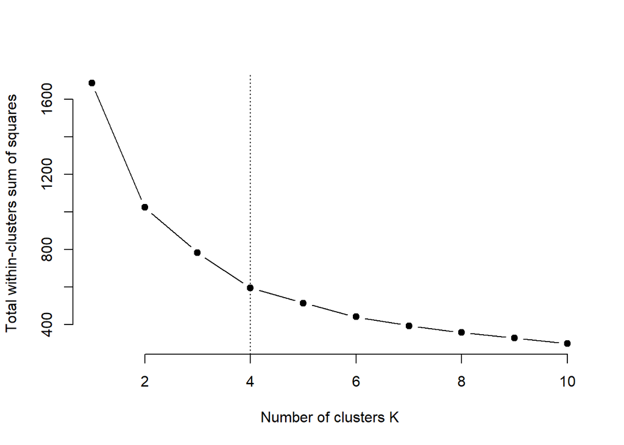

### Cluster description

Next table describe each of the clusters according to their characteristics.

```
--------Summary descriptives table by 'cluster'---------

_________________________________________________________________________
                     1           2           3           4      p.overall
                   N=91        N=86        N=39        N=66
¯¯¯¯¯¯¯¯¯¯¯¯¯¯¯¯¯¯¯¯¯¯¯¯¯¯¯¯¯¯¯¯¯¯¯¯¯¯¯¯¯¯¯¯¯¯¯¯¯¯¯¯¯¯¯¯¯¯¯¯¯¯¯¯¯¯¯¯¯¯¯¯¯
played_minutes  21.0 (4.83) 25.0 (4.24) 41.4 (6.01) 36.3 (5.88)  <0.001
Point           166 (36.2)  185 (31.1)  298 (38.2)  269 (44.8)   <0.001
RallyCount       533 (118)   793 (145)  1317 (193)   887 (128)   <0.001
Dist            1474 (348)  2232 (416)  3633 (536)  2409 (390)   <0.001
rally_min       25.6 (2.72) 32.0 (3.59) 32.0 (4.07) 24.7 (3.23)  <0.001
Dist_min        70.8 (9.78) 89.8 (10.1) 88.2 (9.79) 67.1 (9.59)  <0.001
Speed           174 (7.12)  168 (6.58)  167 (6.10)  174 (6.73)   <0.001
surface:                                                         <0.001
    Clay        13 (14.3%)  19 (22.1%)   5 (12.8%)   5 (7.58%)
    Grass       38 (41.8%)  11 (12.8%)   3 (7.69%)  24 (36.4%)
    Hard        40 (44.0%)  56 (65.1%)  31 (79.5%)  37 (56.1%)
PercFirstServe  61.1 (5.40) 61.3 (5.66) 62.0 (3.70) 61.2 (5.31)   0.855
PercSecondServe 34.9 (4.92) 35.3 (5.10) 34.6 (3.63) 35.0 (4.92)   0.896
PercDoubleFault 4.00 (1.87) 3.44 (1.77) 3.42 (1.21) 3.84 (1.58)   0.098
¯¯¯¯¯¯¯¯¯¯¯¯¯¯¯¯¯¯¯¯¯¯¯¯¯¯¯¯¯¯¯¯¯¯¯¯¯¯¯¯¯¯¯¯¯¯¯¯¯¯¯¯¯¯¯¯¯¯¯¯¯¯¯¯¯¯¯¯¯¯¯¯¯
```

### Interpretation

Long matches are measured with four variables:

- *played_minutes*. Number of effectively played minutes during the match (20% of the total time).
- *Point*. Number of points during the match.
- *RallyCount*. Number of shots (not rallies!) during the match.
- *Dist*. Average distance (meters) covered by the two players of the match.

On the other hand, intensity is measured with two variables:

- *rally_min*. Number of shots per minute.
- *Dist_min*. Average distance (meters) covered by the two players of the match per minute.

There are no relevant differences regarding the percentages of first and second serves and double faults.

## Clustering of players

### Methods

We performed an archetypal analysis to find the most representative players from each cluster analysis.

### Number of clusters

The screeplot say that there is 3 o 4 clusters.

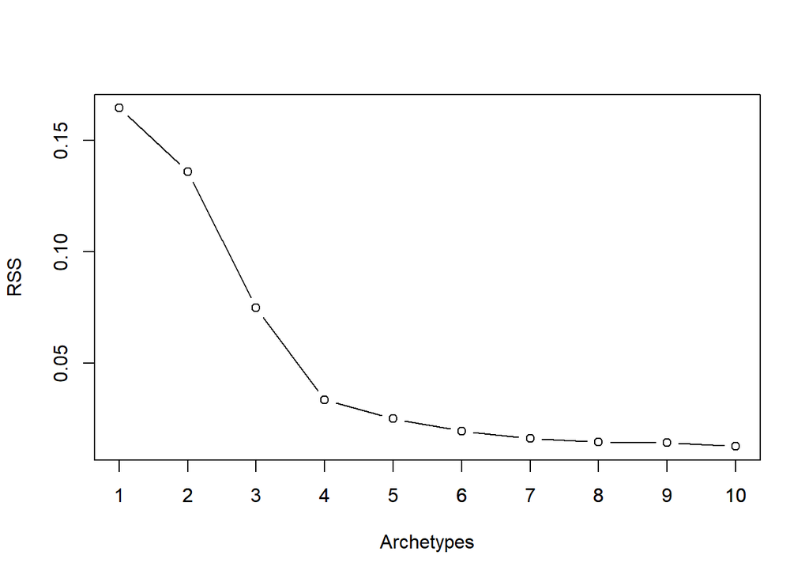

### Cluster description

We decided to take 4 clusters. Next table describe each of the clusters according to their characteristics.

```
--------Summary descriptives table by 'cluster'---------

__________________________________________________________________________
                     1           2           3            4      p.overall
                   N=36        N=51         N=20        N=45
¯¯¯¯¯¯¯¯¯¯¯¯¯¯¯¯¯¯¯¯¯¯¯¯¯¯¯¯¯¯¯¯¯¯¯¯¯¯¯¯¯¯¯¯¯¯¯¯¯¯¯¯¯¯¯¯¯¯¯¯¯¯¯¯¯¯¯¯¯¯¯¯¯¯
played_minutes  84.7 (54.1) 75.2 (55.9)  354 (116)   48.3 (42.3)  <0.001
Point            628 (394)   564 (409)   2620 (807)   379 (332)   <0.001
RallyCount      1377 (866)   937 (655)  4936 (1635)   679 (598)   <0.001
Dist            7507 (4596) 5023 (3565) 27914 (9831) 3753 (3335)  <0.001
rally_match     509 (85.2)  395 (84.8)   400 (41.0)  304 (57.4)   <0.001
Dist_match      2833 (533)  2102 (485)   2259 (257)  1675 (346)   <0.001
rally_min       16.4 (1.43) 12.6 (1.44) 14.0 (1.18)  14.1 (1.17)  <0.001
Dist_min        91.4 (10.3) 67.1 (8.96) 78.8 (7.31)  77.3 (8.15)  <0.001
Speed           165 (6.52)  172 (7.91)   173 (6.87)  170 (8.10)   <0.001
PercFirstServe  61.8 (3.68) 60.5 (5.17) 61.3 (3.17)  60.2 (7.35)   0.585
PercSecondServe 35.0 (3.79) 35.4 (4.75) 35.1 (2.98)  35.7 (7.40)   0.948
PercDoubleFault 3.20 (1.28) 4.02 (1.54) 3.70 (0.91)  4.14 (2.52)   0.091
¯¯¯¯¯¯¯¯¯¯¯¯¯¯¯¯¯¯¯¯¯¯¯¯¯¯¯¯¯¯¯¯¯¯¯¯¯¯¯¯¯¯¯¯¯¯¯¯¯¯¯¯¯¯¯¯¯¯¯¯¯¯¯¯¯¯¯¯¯¯¯¯¯¯
```

### Characteristics

The standarized characteristics of each cluster are:

```
     played_minutes      Point RallyCount       Dist rally_match  Dist_match
[1,]     -0.6061717 -0.6095730 -0.4917294 -0.4654187   2.7291848  2.77856710
[2,]     -0.5213905 -0.4976132 -0.6355755 -0.6468096   0.3906161 -0.06299328
[3,]      3.7591522  3.7627887  3.7301087  3.7348340  -0.1619854 -0.04786683
[4,]     -0.8492135 -0.8668814 -0.8541016 -0.8290891  -2.7925400 -2.61226892
       rally_min    Dist_min
[1,]  2.81723717  2.63361079
[2,] -2.05526745 -2.19649395
[3,] -0.08882534  0.09892209
[4,] -0.03011137  0.18767899
```

## Appendix I: Clustering of matches

### Cluster 1

| match_id | player1 | player2 | Slam | played_minutes | Point | RallyCount | Dist | rally_min | Dist_min | cluster |
| --- | --- | --- | --- | --- | --- | --- | --- | --- | --- | --- |
| 2017-ausopen-1109 | tomas berdych | luca vanni | ausopen | 6.8 | 51 | 191 | 558.4 | 28.1 | 82.3 | 1 |
| 2017-ausopen-1122 | steve darcis | sam groth | ausopen | 26.1 | 207 | 542 | 1073.2 | 20.7 | 41.1 | 1 |
| 2017-ausopen-1124 | gastao elias | nick kyrgios | ausopen | 17.0 | 132 | 432 | 1176.4 | 25.4 | 69.0 | 1 |
| 2017-ausopen-1128 | pierre hugues herbert | jack sock | ausopen | 26.6 | 210 | 594 | 1606.5 | 22.3 | 60.3 | 1 |
| 2017-ausopen-1129 | bernard tomic | thomaz bellucci | ausopen | 19.5 | 154 | 573 | 1524.6 | 29.4 | 78.2 | 1 |
| 2017-ausopen-1141 | roberto bautista agut | guido pella | ausopen | 16.8 | 128 | 506 | 1212.9 | 30.0 | 72.0 | 1 |
| 2017-ausopen-1148 | dustin brown | milos raonic | ausopen | 18.6 | 173 | 455 | 1403.7 | 24.5 | 75.5 | 1 |
| 2017-ausopen-1151 | tommy haas | benoit paire | ausopen | 19.5 | 159 | 462 | 1104.4 | 23.7 | 56.6 | 1 |
| 2017-ausopen-1160 | blake mott | richard gasquet | ausopen | 22.7 | 161 | 607 | 1562.3 | 26.7 | 68.8 | 1 |
| 2017-ausopen-1208 | jeremy chardy | kei nishikori | ausopen | 25.3 | 183 | 682 | 1879.4 | 26.9 | 74.2 | 1 |
| 2017-ausopen-1217 | gael monfils | alexandr dolgopolov | ausopen | 23.4 | 216 | 649 | 1849.1 | 27.7 | 79.0 | 1 |
| 2017-ausopen-1224 | gilles muller | milos raonic | ausopen | 23.9 | 189 | 525 | 1544.1 | 22.0 | 64.7 | 1 |
| 2017-ausopen-1227 | ivo karlovic | andrew whittington | ausopen | 24.2 | 185 | 487 | 1276.0 | 20.1 | 52.7 | 1 |
| 2017-ausopen-1303 | tomas berdych | roger federer | ausopen | 18.1 | 152 | 468 | 1289.6 | 25.9 | 71.3 | 1 |
| 2017-ausopen-1304 | lukas lacko | kei nishikori | ausopen | 26.3 | 183 | 729 | 2008.6 | 27.7 | 76.3 | 1 |
| 2017-ausopen-1314 | ivo karlovic | david goffin | ausopen | 17.6 | 145 | 398 | 1198.6 | 22.6 | 68.2 | 1 |
| 2017-frenchopen-1117 | stan wawrinka | jozef kovalik | frenchopen | 23.5 | 191 | 592 | 1879.8 | 25.1 | 79.8 | 1 |
| 2017-frenchopen-1124 | dustin brown | gael monfils | frenchopen | 18.0 | 177 | 484 | 1572.0 | 26.9 | 87.4 | 1 |
| 2017-frenchopen-1140 | stephane robert | grigor dimitrov | frenchopen | 21.8 | 158 | 589 | 1905.6 | 27.0 | 87.5 | 1 |
| 2017-frenchopen-1148 | benoit paire | rafael nadal | frenchopen | 22.4 | 149 | 535 | 1784.9 | 23.9 | 79.6 | 1 |
| 2017-frenchopen-1149 | dominic thiem | bernard tomic | frenchopen | 16.1 | 141 | 455 | 1341.6 | 28.3 | 83.5 | 1 |
| 2017-frenchopen-1229 | lucas pouille | thomaz bellucci | frenchopen | 25.6 | 189 | 647 | 2081.8 | 25.3 | 81.3 | 1 |
| 2017-frenchopen-1305 | stan wawrinka | fabio fognini | frenchopen | 22.4 | 166 | 580 | 1827.7 | 25.9 | 81.6 | 1 |
| 2017-frenchopen-1308 | feliciano lopez | marin cilic | frenchopen | 21.5 | 153 | 514 | 1624.1 | 23.9 | 75.4 | 1 |
| 2017-frenchopen-1312 | nikoloz basilashvili | rafael nadal | frenchopen | 18.2 | 119 | 439 | 1571.5 | 24.2 | 86.5 | 1 |
| 2017-frenchopen-1314 | horacio zeballos | david goffin | frenchopen | 9.4 | 69 | 266 | 882.3 | 28.3 | 94.0 | 1 |
| 2017-frenchopen-1404 | kevin anderson | marin cilic | frenchopen | 9.4 | 66 | 216 | 626.0 | 23.0 | 66.8 | 1 |
| 2017-frenchopen-1407 | dominic thiem | horacio zeballos | frenchopen | 20.0 | 140 | 496 | 1691.8 | 24.8 | 84.7 | 1 |
| 2017-frenchopen-1502 | stan wawrinka | marin cilic | frenchopen | 20.1 | 146 | 518 | 1794.0 | 25.8 | 89.3 | 1 |
| 2017-usopen-1103 | yuichi sugita | geoffrey blancaneaux | usopen | 20.1 | 142 | 551 | 1557.5 | 27.4 | 77.4 | 1 |

[output cut: 61 more lines]

### Cluster 2

| match_id | player1 | player2 | Slam | played_minutes | Point | RallyCount | Dist | rally_min | Dist_min | cluster |
| --- | --- | --- | --- | --- | --- | --- | --- | --- | --- | --- |
| 2017-ausopen-1112 | jurgen melzer | roger federer | ausopen | 25.2 | 215 | 755 | 1870.6 | 30.0 | 74.3 | 2 |
| 2017-ausopen-1125 | jo wilfried tsonga | thiago monteiro | ausopen | 28.7 | 215 | 798 | 2282.3 | 27.8 | 79.5 | 2 |
| 2017-ausopen-1133 | gael monfils | jiri vesely | ausopen | 18.4 | 147 | 602 | 1642.4 | 32.6 | 89.1 | 2 |
| 2017-ausopen-1140 | florian mayer | rafael nadal | ausopen | 24.9 | 179 | 729 | 2090.4 | 29.3 | 84.0 | 2 |
| 2017-ausopen-1144 | omar jasika | david ferrer | ausopen | 17.3 | 136 | 551 | 1635.4 | 31.9 | 94.8 | 2 |
| 2017-ausopen-1157 | grigor dimitrov | christopher o'connell | ausopen | 24.4 | 192 | 798 | 2274.5 | 32.7 | 93.1 | 2 |
| 2017-ausopen-1164 | fernando verdasco | novak djokovic | ausopen | 28.1 | 201 | 775 | 2189.5 | 27.6 | 78.0 | 2 |
| 2017-ausopen-1201 | andy murray | andrey rublev | ausopen | 19.3 | 135 | 608 | 1604.5 | 31.4 | 82.9 | 2 |
| 2017-ausopen-1202 | alex de minaur | sam querrey | ausopen | 21.7 | 190 | 774 | 2151.6 | 35.7 | 99.3 | 2 |
| 2017-ausopen-1205 | tomas berdych | ryan harrison | ausopen | 25.2 | 205 | 761 | 2040.3 | 30.3 | 81.1 | 2 |
| 2017-ausopen-1206 | noah rubin | roger federer | ausopen | 24.7 | 215 | 738 | 2025.2 | 29.8 | 81.9 | 2 |
| 2017-ausopen-1209 | stan wawrinka | steve johnson | ausopen | 22.3 | 182 | 672 | 2009.6 | 30.1 | 89.9 | 2 |
| 2017-ausopen-1213 | jo wilfried tsonga | dusan lajovic | ausopen | 21.2 | 165 | 656 | 1881.7 | 30.9 | 88.7 | 2 |
| 2017-ausopen-1214 | karen khachanov | jack sock | ausopen | 27.0 | 219 | 800 | 2026.9 | 29.6 | 75.1 | 2 |
| 2017-ausopen-1218 | donald young | philipp kohlschreiber | ausopen | 22.4 | 171 | 709 | 1891.3 | 31.7 | 84.5 | 2 |
| 2017-ausopen-1219 | alexander zverev | frances tiafoe | ausopen | 23.4 | 183 | 723 | 1821.8 | 30.9 | 77.9 | 2 |
| 2017-ausopen-1220 | marcos baghdatis | rafael nadal | ausopen | 26.6 | 179 | 911 | 2484.0 | 34.3 | 93.5 | 2 |
| 2017-ausopen-1221 | roberto bautista agut | yoshihito nishioka | ausopen | 25.8 | 196 | 1093 | 2975.9 | 42.4 | 115.3 | 2 |
| 2017-ausopen-1228 | radek stepanek | david goffin | ausopen | 21.0 | 160 | 654 | 1812.8 | 31.2 | 86.5 | 2 |
| 2017-ausopen-1229 | grigor dimitrov | hyeon chung | ausopen | 31.3 | 222 | 1096 | 2847.0 | 35.0 | 90.9 | 2 |
| 2017-ausopen-1230 | carlos berlocq | richard gasquet | ausopen | 21.1 | 144 | 705 | 1967.4 | 33.4 | 93.1 | 2 |
| 2017-ausopen-1301 | andy murray | sam querrey | ausopen | 23.9 | 174 | 720 | 2004.0 | 30.1 | 83.8 | 2 |
| 2017-ausopen-1302 | mischa zverev | malek jaziri | ausopen | 28.4 | 212 | 975 | 2582.6 | 34.4 | 91.1 | 2 |
| 2017-ausopen-1305 | stan wawrinka | viktor troicki | ausopen | 30.5 | 240 | 954 | 2710.2 | 31.3 | 88.8 | 2 |
| 2017-ausopen-1309 | gael monfils | philipp kohlschreiber | ausopen | 23.1 | 178 | 857 | 2454.3 | 37.1 | 106.2 | 2 |
| 2017-ausopen-1312 | gilles simon | milos raonic | ausopen | 31.0 | 222 | 851 | 2536.3 | 27.4 | 81.7 | 2 |
| 2017-ausopen-1313 | dominic thiem | benoit paire | ausopen | 28.8 | 239 | 892 | 2594.6 | 31.0 | 90.2 | 2 |
| 2017-ausopen-1315 | grigor dimitrov | richard gasquet | ausopen | 24.5 | 178 | 964 | 2720.2 | 39.4 | 111.2 | 2 |
| 2017-ausopen-1408 | grigor dimitrov | denis istomin | ausopen | 29.0 | 203 | 856 | 2445.6 | 29.5 | 84.4 | 2 |
| 2017-ausopen-1501 | mischa zverev | roger federer | ausopen | 18.5 | 177 | 601 | 1564.4 | 32.4 | 84.4 | 2 |

[output cut: 56 more lines]

### Cluster 3

| match_id | player1 | player2 | Slam | played_minutes | Point | RallyCount | Dist | rally_min | Dist_min | cluster |
| --- | --- | --- | --- | --- | --- | --- | --- | --- | --- | --- |
| 2017-ausopen-1103 | alex de minaur | gerald melzer | ausopen | 44.5 | 325 | 1451 | 4275.8 | 32.6 | 96.1 | 3 |
| 2017-ausopen-1117 | stan wawrinka | martin klizan | ausopen | 40.9 | 318 | 1088 | 3348.0 | 26.6 | 81.9 | 3 |
| 2017-ausopen-1137 | alexander zverev | robin haase | ausopen | 35.0 | 285 | 1055 | 2838.7 | 30.2 | 81.2 | 3 |
| 2017-ausopen-1150 | jordan thompson | joao sousa | ausopen | 40.2 | 279 | 1257 | 3218.0 | 31.3 | 80.0 | 3 |
| 2017-ausopen-1210 | paolo lorenzi | viktor troicki | ausopen | 45.5 | 315 | 1546 | 3746.3 | 34.0 | 82.4 | 3 |
| 2017-ausopen-1212 | andreas seppi | nick kyrgios | ausopen | 37.8 | 322 | 1263 | 3025.7 | 33.4 | 80.0 | 3 |
| 2017-ausopen-1215 | bernard tomic | victor estrella burgos | ausopen | 40.1 | 299 | 1558 | 4392.1 | 38.8 | 109.4 | 3 |
| 2017-ausopen-1216 | daniel evans | marin cilic | ausopen | 35.6 | 254 | 1098 | 2933.3 | 30.9 | 82.4 | 3 |
| 2017-ausopen-1226 | benoit paire | fabio fognini | ausopen | 41.9 | 337 | 1314 | 3586.8 | 31.4 | 85.7 | 3 |
| 2017-ausopen-1232 | denis istomin | novak djokovic | ausopen | 58.0 | 380 | 1716 | 4676.5 | 29.6 | 80.7 | 3 |
| 2017-ausopen-1306 | steve darcis | andreas seppi | ausopen | 37.5 | 263 | 1368 | 3598.5 | 36.5 | 96.0 | 3 |
| 2017-ausopen-1307 | jo wilfried tsonga | jack sock | ausopen | 42.6 | 322 | 1092 | 3321.3 | 25.6 | 77.9 | 3 |
| 2017-ausopen-1308 | bernard tomic | daniel evans | ausopen | 33.7 | 249 | 1259 | 3503.7 | 37.4 | 104.0 | 3 |
| 2017-ausopen-1310 | alexander zverev | rafael nadal | ausopen | 49.2 | 323 | 1439 | 3960.7 | 29.2 | 80.5 | 3 |
| 2017-ausopen-1311 | roberto bautista agut | david ferrer | ausopen | 48.5 | 334 | 1885 | 5282.1 | 38.9 | 109.0 | 3 |
| 2017-ausopen-1316 | pablo carreno busta | denis istomin | ausopen | 41.5 | 293 | 1400 | 3608.3 | 33.8 | 87.0 | 3 |
| 2017-ausopen-1401 | andy murray | mischa zverev | ausopen | 42.9 | 283 | 1225 | 3353.1 | 28.6 | 78.2 | 3 |
| 2017-ausopen-1701 | roger federer | rafael nadal | ausopen | 43.5 | 290 | 1217 | 3273.7 | 28.0 | 75.3 | 3 |
| 2017-frenchopen-1125 | jo wilfried tsonga | renzo olivo | frenchopen | 42.5 | 327 | 1205 | 3864.3 | 28.4 | 91.0 | 3 |
| 2017-frenchopen-1306 | richard gasquet | gael monfils | frenchopen | 36.5 | 207 | 1158 | 3343.6 | 31.7 | 91.5 | 3 |
| 2017-frenchopen-1315 | lucas pouille | albert ramos vinolas | frenchopen | 44.4 | 308 | 1144 | 3744.5 | 25.8 | 84.4 | 3 |
| 2017-frenchopen-1316 | diego schwartzman | novak djokovic | frenchopen | 39.8 | 268 | 1107 | 3516.5 | 27.8 | 88.4 | 3 |
| 2017-frenchopen-1601 | andy murray | stan wawrinka | frenchopen | 54.8 | 340 | 1525 | 5011.9 | 27.8 | 91.4 | 3 |
| 2017-usopen-1141 | jack sock | jordan thompson | usopen | 47.3 | 337 | 1337 | 3599.5 | 28.3 | 76.2 | 3 |
| 2017-usopen-1148 | darian king | alexander zverev | usopen | 34.0 | 264 | 1388 | 3572.6 | 40.9 | 105.2 | 3 |
| 2017-usopen-1162 | thanasi kokkinakis | janko tipsarevic | usopen | 50.1 | 354 | 1281 | 3509.2 | 25.6 | 70.0 | 3 |
| 2017-usopen-1164 | tennys sandgren | marin cilic | usopen | 33.6 | 238 | 1178 | 3356.1 | 35.1 | 99.9 | 3 |
| 2017-usopen-1201 | rafael nadal | taro daniel | usopen | 34.7 | 226 | 1180 | 3588.6 | 34.0 | 103.3 | 3 |
| 2017-usopen-1205 | david goffin | guido pella | usopen | 52.1 | 361 | 1700 | 4298.2 | 32.7 | 82.6 | 3 |
| 2017-usopen-1206 | donald young | gael monfils | usopen | 39.4 | 310 | 1269 | 3645.2 | 32.2 | 92.6 | 3 |
| 2017-usopen-1209 | roger federer | mikhail youzhny | usopen | 37.6 | 319 | 1249 | 3454.8 | 33.2 | 91.8 | 3 |
| 2017-usopen-1216 | taylor fritz | dominic thiem | usopen | 34.0 | 280 | 1046 | 2826.6 | 30.7 | 83.1 | 3 |
| 2017-usopen-1224 | borna coric | alexander zverev | usopen | 41.3 | 301 | 1412 | 3470.3 | 34.2 | 84.0 | 3 |
| 2017-usopen-1304 | damir dzumhur | andrey rublev | usopen | 33.2 | 276 | 1361 | 3447.9 | 41.0 | 103.8 | 3 |
| 2017-usopen-1316 | diego schwartzman | marin cilic | usopen | 40.8 | 286 | 1411 | 3691.1 | 34.6 | 90.6 | 3 |
| 2017-usopen-1404 | juan martin del potro | dominic thiem | usopen | 42.9 | 282 | 1319 | 3692.6 | 30.7 | 86.1 | 3 |
| 2017-wimbledon-1153 | richard gasquet | david ferrer | wimbledon | 34.8 | 251 | 1158 | 3015.1 | 33.2 | 86.6 | 3 |
| 2017-wimbledon-1307 | kei nishikori | roberto bautista agut | wimbledon | 40.2 | 293 | 1170 | 3247.0 | 29.1 | 80.7 | 3 |
| 2017-wimbledon-1315 | gael monfils | adrian mannarino | wimbledon | 42.1 | 340 | 1527 | 3837.2 | 36.3 | 91.2 | 3 |

### Cluster 4

| match_id | player1 | player2 | Slam | played_minutes | Point | RallyCount | Dist | rally_min | Dist_min | cluster |
| --- | --- | --- | --- | --- | --- | --- | --- | --- | --- | --- |
| 2017-ausopen-1101 | andy murray | illya marchenko | ausopen | 33.5 | 212 | 904 | 2541.1 | 27.0 | 75.9 | 4 |
| 2017-ausopen-1104 | quentin halys | sam querrey | ausopen | 33.2 | 285 | 746 | 1834.4 | 22.5 | 55.3 | 4 |
| 2017-ausopen-1116 | andrey kuznetsov | kei nishikori | ausopen | 42.9 | 301 | 1091 | 2799.3 | 25.4 | 65.2 | 4 |
| 2017-ausopen-1119 | james duckworth | paolo lorenzi | ausopen | 39.2 | 284 | 1101 | 2716.8 | 28.1 | 69.3 | 4 |
| 2017-ausopen-1132 | jerzy janowicz | marin cilic | ausopen | 37.0 | 269 | 663 | 1851.7 | 17.9 | 50.1 | 4 |
| 2017-ausopen-1142 | yoshihito nishioka | alex bolt | ausopen | 30.0 | 234 | 872 | 2236.1 | 29.0 | 74.4 | 4 |
| 2017-ausopen-1149 | dominic thiem | jan lennard struff | ausopen | 34.9 | 273 | 949 | 2474.3 | 27.2 | 71.0 | 4 |
| 2017-ausopen-1156 | reilly opelka | david goffin | ausopen | 35.3 | 293 | 781 | 2196.0 | 22.1 | 62.2 | 4 |
| 2017-ausopen-1203 | john isner | mischa zverev | ausopen | 50.2 | 417 | 972 | 2742.4 | 19.4 | 54.7 | 4 |
| 2017-ausopen-1222 | ernesto escobedo | david ferrer | ausopen | 33.3 | 263 | 973 | 2604.3 | 29.2 | 78.2 | 4 |
| 2017-ausopen-1225 | dominic thiem | jordan thompson | ausopen | 32.8 | 237 | 899 | 2567.6 | 27.4 | 78.2 | 4 |
| 2017-ausopen-1402 | roger federer | kei nishikori | ausopen | 40.8 | 313 | 1044 | 2883.9 | 25.6 | 70.7 | 4 |
| 2017-ausopen-1403 | stan wawrinka | andreas seppi | ausopen | 32.8 | 254 | 992 | 2275.2 | 30.3 | 69.4 | 4 |
| 2017-ausopen-1404 | jo wilfried tsonga | daniel evans | ausopen | 34.7 | 266 | 972 | 2967.8 | 28.0 | 85.6 | 4 |
| 2017-ausopen-1405 | gael monfils | rafael nadal | ausopen | 35.2 | 232 | 986 | 2956.9 | 28.0 | 84.1 | 4 |
| 2017-ausopen-1406 | roberto bautista agut | milos raonic | ausopen | 34.4 | 241 | 869 | 2506.0 | 25.3 | 72.9 | 4 |
| 2017-ausopen-1407 | dominic thiem | david goffin | ausopen | 32.8 | 254 | 954 | 2591.4 | 29.1 | 79.1 | 4 |
| 2017-ausopen-1503 | rafael nadal | milos raonic | ausopen | 32.9 | 213 | 794 | 2475.3 | 24.1 | 75.2 | 4 |
| 2017-ausopen-1601 | roger federer | stan wawrinka | ausopen | 36.9 | 279 | 1023 | 2522.1 | 27.7 | 68.3 | 4 |
| 2017-frenchopen-1109 | alexander zverev | fernando verdasco | frenchopen | 42.1 | 256 | 1091 | 3311.3 | 25.9 | 78.6 | 4 |
| 2017-frenchopen-1157 | lucas pouille | julien benneteau | frenchopen | 40.2 | 298 | 823 | 2553.6 | 20.5 | 63.5 | 4 |
| 2017-frenchopen-1201 | andy murray | martin klizan | frenchopen | 43.0 | 263 | 1059 | 3359.2 | 24.7 | 78.2 | 4 |
| 2017-frenchopen-1209 | stan wawrinka | alexandr dolgopolov | frenchopen | 30.8 | 227 | 733 | 2258.9 | 23.8 | 73.2 | 4 |
| 2017-frenchopen-1225 | dominic thiem | simone bolelli | frenchopen | 28.6 | 215 | 702 | 2258.8 | 24.6 | 79.0 | 4 |
| 2017-usopen-1104 | leonardo mayer | richard gasquet | usopen | 34.1 | 228 | 944 | 2572.3 | 27.7 | 75.4 | 4 |
| 2017-usopen-1117 | roger federer | frances tiafoe | usopen | 31.5 | 256 | 849 | 2353.0 | 26.9 | 74.7 | 4 |
| 2017-usopen-1120 | andrey kuznetsov | feliciano lopez | usopen | 35.1 | 285 | 914 | 2447.6 | 26.1 | 69.8 | 4 |
| 2017-usopen-1128 | henri laaksonen | juan martin del potro | usopen | 30.8 | 230 | 847 | 2359.6 | 27.5 | 76.5 | 4 |
| 2017-usopen-1139 | horacio zeballos | hyeon chung | usopen | 42.0 | 289 | 1173 | 2931.0 | 27.9 | 69.8 | 4 |
| 2017-usopen-1144 | bernard tomic | gilles muller | usopen | 30.7 | 251 | 798 | 1903.8 | 26.0 | 62.1 | 4 |
| 2017-usopen-1151 | nicolas almagro | steve johnson | usopen | 28.5 | 212 | 769 | 1977.5 | 27.0 | 69.5 | 4 |
| 2017-usopen-1202 | yuichi sugita | leonardo mayer | usopen | 35.8 | 260 | 936 | 2591.4 | 26.1 | 72.4 | 4 |
| 2017-usopen-1204 | alexandr dolgopolov | tomas berdych | usopen | 31.5 | 236 | 784 | 2038.8 | 24.9 | 64.7 | 4 |
| 2017-usopen-1208 | andrey rublev | grigor dimitrov | usopen | 29.4 | 232 | 840 | 2195.3 | 28.5 | 74.6 | 4 |
| 2017-usopen-1229 | lucas pouille | jared donaldson | usopen | 41.5 | 319 | 1030 | 2664.9 | 24.8 | 64.3 | 4 |
| 2017-usopen-1301 | rafael nadal | leonardo mayer | usopen | 39.1 | 262 | 968 | 2724.6 | 24.7 | 69.7 | 4 |
| 2017-usopen-1315 | lucas pouille | mikhail kukushkin | usopen | 28.2 | 226 | 782 | 2049.9 | 27.7 | 72.7 | 4 |
| 2017-usopen-1406 | paolo lorenzi | kevin anderson | usopen | 35.4 | 235 | 876 | 2192.4 | 24.7 | 61.9 | 4 |
| 2017-usopen-1407 | denis shapovalov | pablo carreno busta | usopen | 34.9 | 254 | 997 | 2736.6 | 28.6 | 78.5 | 4 |
| 2017-usopen-1502 | roger federer | juan martin del potro | usopen | 34.3 | 258 | 862 | 2212.0 | 25.1 | 64.4 | 4 |
| 2017-usopen-1503 | sam querrey | kevin anderson | usopen | 41.4 | 302 | 927 | 2456.0 | 22.4 | 59.4 | 4 |
| 2017-usopen-1602 | kevin anderson | pablo carreno busta | usopen | 35.0 | 249 | 931 | 2391.9 | 26.6 | 68.4 | 4 |
| 2017-wimbledon-1113 | fernando verdasco | kevin anderson | wimbledon | 43.4 | 268 | 794 | 2143.6 | 18.3 | 49.4 | 4 |
| 2017-wimbledon-1121 | ivo karlovic | aljaz bedene | wimbledon | 53.0 | 400 | 905 | 2453.7 | 17.1 | 46.3 | 4 |
| 2017-wimbledon-1161 | juan martin del potro | thanasi kokkinakis | wimbledon | 36.7 | 255 | 862 | 2204.9 | 23.5 | 60.0 | 4 |
| 2017-wimbledon-1204 | jerzy janowicz | lucas pouille | wimbledon | 33.1 | 263 | 720 | 1940.0 | 21.7 | 58.6 | 4 |
| 2017-wimbledon-1212 | lukas rosol | gilles muller | wimbledon | 43.5 | 357 | 884 | 2260.4 | 20.3 | 51.9 | 4 |
| 2017-wimbledon-1213 | kei nishikori | sergiy stakhovsky | wimbledon | 39.1 | 281 | 964 | 2725.5 | 24.6 | 69.7 | 4 |
| 2017-wimbledon-1215 | steve johnson | radu albot | wimbledon | 30.4 | 236 | 764 | 2236.6 | 25.1 | 73.5 | 4 |
| 2017-wimbledon-1217 | milos raonic | mikhail youzhny | wimbledon | 32.1 | 248 | 688 | 1885.1 | 21.5 | 58.8 | 4 |
| 2017-wimbledon-1218 | andrey rublev | albert ramos vinolas | wimbledon | 42.4 | 321 | 1160 | 2853.0 | 27.3 | 67.2 | 4 |
| 2017-wimbledon-1222 | dudi sela | john isner | wimbledon | 46.3 | 367 | 1016 | 2664.6 | 22.0 | 57.6 | 4 |
| 2017-wimbledon-1225 | dominic thiem | gilles simon | wimbledon | 34.4 | 260 | 955 | 2952.7 | 27.8 | 85.9 | 4 |
| 2017-wimbledon-1228 | ryan harrison | tomas berdych | wimbledon | 31.4 | 246 | 722 | 1771.2 | 23.0 | 56.3 | 4 |
| 2017-wimbledon-1231 | juan martin del potro | ernests gulbis | wimbledon | 34.9 | 213 | 636 | 1552.2 | 18.2 | 44.5 | 4 |
| 2017-wimbledon-1301 | andy murray | fabio fognini | wimbledon | 31.9 | 222 | 913 | 2283.0 | 28.7 | 71.6 | 4 |
| 2017-wimbledon-1303 | jo wilfried tsonga | sam querrey | wimbledon | 36.0 | 299 | 847 | 2354.8 | 23.5 | 65.4 | 4 |
| 2017-wimbledon-1306 | aljaz bedene | gilles muller | wimbledon | 29.5 | 222 | 678 | 1848.3 | 23.0 | 62.7 | 4 |
| 2017-wimbledon-1402 | sam querrey | kevin anderson | wimbledon | 37.5 | 320 | 745 | 1893.4 | 19.9 | 50.5 | 4 |
| 2017-wimbledon-1403 | rafael nadal | gilles muller | wimbledon | 57.6 | 390 | 1156 | 3426.5 | 20.1 | 59.5 | 4 |
| 2017-wimbledon-1405 | milos raonic | alexander zverev | wimbledon | 40.7 | 311 | 931 | 2620.2 | 22.9 | 64.4 | 4 |
| 2017-wimbledon-1407 | dominic thiem | tomas berdych | wimbledon | 34.6 | 274 | 794 | 2094.1 | 22.9 | 60.5 | 4 |
| 2017-wimbledon-1501 | andy murray | sam querrey | wimbledon | 32.4 | 249 | 868 | 2223.9 | 26.8 | 68.6 | 4 |
| 2017-wimbledon-1502 | gilles muller | marin cilic | wimbledon | 42.0 | 303 | 780 | 2191.7 | 18.6 | 52.2 | 4 |
| 2017-wimbledon-1601 | sam querrey | marin cilic | wimbledon | 35.2 | 272 | 825 | 2142.2 | 23.4 | 60.8 | 4 |
| 2017-wimbledon-1602 | roger federer | tomas berdych | wimbledon | 27.7 | 234 | 734 | 2005.6 | 26.5 | 72.3 | 4 |

## Appendix II: Clustering of players

### Cluster 1

| Player | played_minutes | Point | RallyCount | Dist | rally_match | Dist_match | rally_min | Dist_min | cluster |
| --- | --- | --- | --- | --- | --- | --- | --- | --- | --- |
| alex de minaur | 87.2 | 670 | 1477.0 | 8866.5 | 492.3 | 2955.5 | 16.9 | 101.7 | 1 |
| bernard tomic | 140.1 | 1094 | 2321.5 | 11768.7 | 464.3 | 2353.7 | 16.6 | 84.0 | 1 |
| roberto bautista agut | 234.1 | 1654 | 3795.5 | 21508.3 | 474.4 | 2688.5 | 16.2 | 91.9 | 1 |
| yoshihito nishioka | 55.9 | 430 | 982.5 | 5115.1 | 491.2 | 2557.6 | 17.6 | 91.6 | 1 |
| jordan thompson | 120.3 | 853 | 1746.5 | 9679.5 | 582.2 | 3226.5 | 14.5 | 80.5 | 1 |
| paolo lorenzi | 146.7 | 1009 | 2261.0 | 11569.2 | 565.2 | 2892.3 | 15.4 | 78.9 | 1 |
| andreas seppi | 108.1 | 839 | 1811.5 | 9135.4 | 603.8 | 3045.1 | 16.8 | 84.5 | 1 |
| daniel evans | 104.0 | 769 | 1664.5 | 9706.7 | 554.8 | 3235.6 | 16.0 | 93.4 | 1 |
| donald young | 88.0 | 671 | 1324.0 | 7799.2 | 441.3 | 2599.7 | 15.0 | 88.6 | 1 |
| denis istomin | 128.4 | 876 | 1986.0 | 10523.0 | 662.0 | 3507.7 | 15.5 | 81.9 | 1 |
| gilles simon | 87.9 | 664 | 1246.0 | 7427.2 | 415.3 | 2475.7 | 14.2 | 84.5 | 1 |
| pablo carreno busta | 165.4 | 1189 | 2566.5 | 13591.7 | 427.8 | 2265.3 | 15.5 | 82.2 | 1 |
| marcel granollers | 29.4 | 190 | 443.0 | 2728.0 | 443.0 | 2728.0 | 15.1 | 92.8 | 1 |
| joao sousa | 65.6 | 451 | 1010.0 | 5414.7 | 505.0 | 2707.4 | 15.4 | 82.6 | 1 |
| diego schwartzman | 157.4 | 1141 | 2519.0 | 13659.3 | 503.8 | 2731.9 | 16.0 | 86.8 | 1 |
| vaclav safranek | 21.8 | 178 | 396.0 | 2450.1 | 396.0 | 2450.1 | 18.2 | 112.4 | 1 |
| john millman | 100.2 | 768 | 1808.5 | 9218.8 | 452.1 | 2304.7 | 18.0 | 92.0 | 1 |
| darian king | 34.0 | 264 | 694.0 | 3831.4 | 694.0 | 3831.4 | 20.4 | 112.8 | 1 |
| tennys sandgren | 33.6 | 238 | 589.0 | 3479.7 | 589.0 | 3479.7 | 17.5 | 103.6 | 1 |
| andrey rublev | 168.7 | 1331 | 2656.5 | 13537.7 | 442.8 | 2256.3 | 15.7 | 80.2 | 1 |
| malek jaziri | 52.3 | 398 | 917.0 | 4599.3 | 458.5 | 2299.7 | 17.5 | 87.9 | 1 |
| adrian mannarino | 149.4 | 1121 | 2629.5 | 13506.2 | 525.9 | 2701.2 | 17.6 | 90.4 | 1 |
| taylor fritz | 57.8 | 474 | 924.5 | 4606.3 | 462.2 | 2303.2 | 16.0 | 79.7 | 1 |
| viktor troicki | 117.3 | 886 | 1850.5 | 9303.3 | 462.6 | 2325.8 | 15.8 | 79.3 | 1 |
| damir dzumhur | 58.7 | 473 | 1071.5 | 5777.2 | 535.8 | 2888.6 | 18.2 | 98.4 | 1 |
| thomas fabbiano | 26.5 | 175 | 499.5 | 2561.8 | 499.5 | 2561.8 | 18.8 | 96.6 | 1 |
| daniil medvedev | 26.5 | 220 | 415.5 | 2349.4 | 415.5 | 2349.4 | 15.7 | 88.7 | 1 |
| david ferrer | 155.0 | 1153 | 2599.0 | 14631.6 | 519.8 | 2926.3 | 16.8 | 94.4 | 1 |
| gerald melzer | 44.5 | 325 | 725.5 | 3974.3 | 725.5 | 3974.3 | 16.3 | 89.3 | 1 |
| guido pella | 68.9 | 489 | 1103.0 | 5685.6 | 551.5 | 2842.8 | 16.0 | 82.5 | 1 |
| christopher o'connell | 24.4 | 192 | 399.0 | 2216.2 | 399.0 | 2216.2 | 16.3 | 90.7 | 1 |
| victor estrella burgos | 60.9 | 453 | 1126.0 | 7434.3 | 563.0 | 3717.2 | 18.5 | 122.0 | 1 |
| arthur de greef | 26.2 | 196 | 361.0 | 2617.6 | 361.0 | 2617.6 | 13.8 | 100.1 | 1 |
| renzo olivo | 42.5 | 327 | 602.5 | 4025.3 | 602.5 | 4025.3 | 14.2 | 94.8 | 1 |
| taro daniel | 34.7 | 226 | 590.0 | 3650.8 | 590.0 | 3650.8 | 17.0 | 105.1 | 1 |
| bjorn fratangelo | 27.5 | 215 | 442.5 | 2289.6 | 442.5 | 2289.6 | 16.1 | 83.3 | 1 |

### Cluster 2

| Player | played_minutes | Point | RallyCount | Dist | rally_match | Dist_match | rally_min | Dist_min | cluster |
| --- | --- | --- | --- | --- | --- | --- | --- | --- | --- |
| quentin halys | 33.2 | 285 | 373.0 | 1804.8 | 373.0 | 1804.8 | 11.2 | 54.4 | 2 |
| andrey kuznetsov | 108.4 | 787 | 1401.0 | 7495.6 | 467.0 | 2498.5 | 12.9 | 69.1 | 2 |
| james duckworth | 39.2 | 284 | 550.5 | 2649.4 | 550.5 | 2649.4 | 14.0 | 67.5 | 2 |
| steve darcis | 63.6 | 470 | 955.0 | 4522.8 | 477.5 | 2261.4 | 15.0 | 71.1 | 2 |
| pierre hugues herbert | 64.8 | 533 | 717.0 | 3996.3 | 239.0 | 1332.1 | 11.1 | 61.7 | 2 |
| jerzy janowicz | 90.6 | 716 | 932.0 | 4719.6 | 310.7 | 1573.2 | 10.3 | 52.1 | 2 |
| reilly opelka | 35.3 | 293 | 390.5 | 2108.0 | 390.5 | 2108.0 | 11.1 | 59.7 | 2 |
| fernando verdasco | 170.8 | 1150 | 2217.0 | 12245.0 | 443.4 | 2449.0 | 13.0 | 71.7 | 2 |
| john isner | 169.6 | 1366 | 1785.5 | 9726.0 | 357.1 | 1945.2 | 10.5 | 57.3 | 2 |
| jeremy chardy | 79.3 | 609 | 1023.5 | 5336.8 | 341.2 | 1778.9 | 12.9 | 67.3 | 2 |
| karen khachanov | 105.8 | 791 | 1444.5 | 7586.4 | 361.1 | 1896.6 | 13.7 | 71.7 | 2 |
| ernesto escobedo | 33.3 | 263 | 486.5 | 2600.1 | 486.5 | 2600.1 | 14.6 | 78.1 | 2 |
| gilles muller | 250.4 | 1902 | 2677.5 | 14574.9 | 382.5 | 2082.1 | 10.7 | 58.2 | 2 |
| ivo karlovic | 94.8 | 730 | 895.0 | 5241.1 | 298.3 | 1747.0 | 9.4 | 55.3 | 2 |
| kevin anderson | 298.4 | 2140 | 3378.0 | 17745.1 | 337.8 | 1774.5 | 11.3 | 59.5 | 2 |
| albert ramos vinolas | 144.6 | 1040 | 2016.5 | 11428.2 | 504.1 | 2857.1 | 13.9 | 79.0 | 2 |
| yuichi sugita | 55.9 | 402 | 743.5 | 3999.9 | 371.8 | 1999.9 | 13.3 | 71.5 | 2 |
| leonardo mayer | 109.0 | 750 | 1424.0 | 8022.8 | 474.7 | 2674.3 | 13.1 | 73.6 | 2 |
| ryan harrison | 82.0 | 645 | 1100.5 | 5423.6 | 366.8 | 1807.9 | 13.4 | 66.1 | 2 |
| henri laaksonen | 30.8 | 230 | 423.5 | 2416.1 | 423.5 | 2416.1 | 13.7 | 78.3 | 2 |
| yen hsun lu | 26.9 | 213 | 353.0 | 1791.8 | 353.0 | 1791.8 | 13.1 | 66.5 | 2 |
| jack sock | 143.5 | 1088 | 1911.5 | 10489.9 | 477.9 | 2622.5 | 13.3 | 73.1 | 2 |
| nicolas almagro | 28.5 | 212 | 384.5 | 1920.5 | 384.5 | 1920.5 | 13.5 | 67.5 | 2 |
| thanasi kokkinakis | 86.9 | 609 | 1071.5 | 5766.1 | 535.8 | 2883.0 | 12.3 | 66.4 | 2 |
| adrian menendez maceiras | 26.0 | 184 | 320.0 | 1961.5 | 320.0 | 1961.5 | 12.3 | 75.3 | 2 |
| hyeon chung | 94.6 | 683 | 1378.0 | 6942.3 | 459.3 | 2314.1 | 14.6 | 73.4 | 2 |
| borna coric | 63.3 | 462 | 960.0 | 4521.6 | 480.0 | 2260.8 | 15.2 | 71.4 | 2 |
| denis shapovalov | 86.0 | 633 | 1196.5 | 6777.7 | 398.8 | 2259.2 | 13.9 | 78.8 | 2 |
| marton fucsovics | 23.2 | 190 | 267.0 | 1574.3 | 267.0 | 1574.3 | 11.5 | 67.9 | 2 |
| evgeny donskoy | 22.1 | 185 | 274.5 | 1412.9 | 274.5 | 1412.9 | 12.4 | 63.9 | 2 |
| martin klizan | 91.9 | 648 | 1157.5 | 6955.0 | 385.8 | 2318.3 | 12.6 | 75.7 | 2 |
| aljaz bedene | 108.0 | 819 | 1182.5 | 6236.0 | 394.2 | 2078.7 | 11.0 | 57.8 | 2 |
| lukas rosol | 43.5 | 357 | 442.0 | 2147.3 | 442.0 | 2147.3 | 10.2 | 49.3 | 2 |
| dudi sela | 74.4 | 593 | 940.5 | 4793.4 | 313.5 | 1597.8 | 12.6 | 64.4 | 2 |
| ernests gulbis | 61.3 | 405 | 630.0 | 3136.9 | 315.0 | 1568.4 | 10.3 | 51.1 | 2 |
| illya marchenko | 33.5 | 212 | 452.0 | 2468.6 | 452.0 | 2468.6 | 13.5 | 73.7 | 2 |
| sam groth | 26.1 | 207 | 271.0 | 1136.8 | 271.0 | 1136.8 | 10.4 | 43.5 | 2 |
| alex bolt | 30.0 | 234 | 436.0 | 2266.5 | 436.0 | 2266.5 | 14.5 | 75.4 | 2 |
| jan lennard struff | 62.1 | 493 | 761.0 | 4017.9 | 380.5 | 2009.0 | 12.3 | 64.7 | 2 |
| fabio fognini | 119.6 | 918 | 1704.5 | 9040.1 | 426.1 | 2260.0 | 14.3 | 75.6 | 2 |
| andrew whittington | 24.2 | 185 | 243.5 | 1205.0 | 243.5 | 1205.0 | 10.1 | 49.7 | 2 |
| julien benneteau | 67.8 | 515 | 850.5 | 4783.2 | 425.2 | 2391.6 | 12.5 | 70.5 | 2 |
| simone bolelli | 51.6 | 391 | 663.5 | 3940.1 | 331.8 | 1970.0 | 12.9 | 76.4 | 2 |
| ruben bemelmans | 44.5 | 376 | 567.5 | 2786.7 | 283.8 | 1393.3 | 12.7 | 62.6 | 2 |
| janko tipsarevic | 50.1 | 354 | 640.5 | 3519.2 | 640.5 | 3519.2 | 12.8 | 70.2 | 2 |
| mikhail youzhny | 69.7 | 567 | 968.5 | 5438.2 | 484.2 | 2719.1 | 13.9 | 78.0 | 2 |
| jared donaldson | 66.1 | 503 | 879.5 | 4729.0 | 439.8 | 2364.5 | 13.3 | 71.5 | 2 |
| radu albot | 56.0 | 447 | 785.5 | 4518.8 | 392.8 | 2259.4 | 14.0 | 80.6 | 2 |
| mikhail kukushkin | 28.2 | 226 | 391.0 | 1998.6 | 391.0 | 1998.6 | 13.9 | 70.8 | 2 |
| alexander ward | 24.6 | 201 | 292.5 | 1449.9 | 292.5 | 1449.9 | 11.9 | 58.9 | 2 |
| sergiy stakhovsky | 39.1 | 281 | 482.0 | 2816.6 | 482.0 | 2816.6 | 12.3 | 72.0 | 2 |

### Cluster 3

| Player | played_minutes | Point | RallyCount | Dist | rally_match | Dist_match | rally_min | Dist_min | cluster |
| --- | --- | --- | --- | --- | --- | --- | --- | --- | --- |
| andy murray | 474.8 | 3199 | 6544.0 | 38322.8 | 436.3 | 2554.9 | 13.8 | 80.7 | 3 |
| tomas berdych | 263.0 | 2074 | 3423.0 | 18057.7 | 311.2 | 1641.6 | 13.0 | 68.7 | 3 |
| stan wawrinka | 426.4 | 3127 | 6027.0 | 35441.1 | 430.5 | 2531.5 | 14.1 | 83.1 | 3 |
| jo wilfried tsonga | 321.0 | 2498 | 4394.0 | 25488.0 | 399.5 | 2317.1 | 13.7 | 79.4 | 3 |
| gael monfils | 372.7 | 2855 | 5911.0 | 33817.5 | 422.2 | 2415.5 | 15.9 | 90.7 | 3 |
| alexander zverev | 325.0 | 2433 | 4777.0 | 25456.9 | 477.7 | 2545.7 | 14.7 | 78.3 | 3 |
| dominic thiem | 487.7 | 3650 | 7034.0 | 41359.5 | 413.8 | 2432.9 | 14.4 | 84.8 | 3 |
| grigor dimitrov | 283.0 | 2125 | 4532.0 | 26018.0 | 377.7 | 2168.2 | 16.0 | 92.0 | 3 |
| mischa zverev | 202.6 | 1621 | 2627.0 | 15891.3 | 375.3 | 2270.2 | 13.0 | 78.4 | 3 |
| roger federer | 494.0 | 4016 | 6687.0 | 35328.9 | 351.9 | 1859.4 | 13.5 | 71.5 | 3 |
| rafael nadal | 688.6 | 4612 | 9485.0 | 56342.3 | 395.2 | 2347.6 | 13.8 | 81.8 | 3 |
| david goffin | 262.1 | 2026 | 4005.0 | 21655.0 | 400.5 | 2165.5 | 15.3 | 82.6 | 3 |
| richard gasquet | 220.7 | 1519 | 3476.0 | 19356.9 | 434.5 | 2419.6 | 15.7 | 87.7 | 3 |
| lucas pouille | 264.4 | 2033 | 3402.0 | 19625.3 | 425.2 | 2453.2 | 12.9 | 74.2 | 3 |
| sam querrey | 363.2 | 2981 | 4663.5 | 24586.5 | 358.7 | 1891.3 | 12.8 | 67.7 | 3 |
| juan martin del potro | 296.7 | 1991 | 3921.0 | 21389.7 | 435.7 | 2376.6 | 13.2 | 72.1 | 3 |
| kei nishikori | 291.9 | 2101 | 3953.5 | 21965.0 | 439.3 | 2440.6 | 13.5 | 75.2 | 3 |
| milos raonic | 292.7 | 2215 | 3455.0 | 20106.3 | 345.5 | 2010.6 | 11.8 | 68.7 | 3 |
| marin cilic | 411.8 | 3043 | 5354.0 | 29940.1 | 356.9 | 1996.0 | 13.0 | 72.7 | 3 |
| novak djokovic | 329.9 | 2291 | 5054.5 | 28135.2 | 421.2 | 2344.6 | 15.3 | 85.3 | 3 |

### Cluster 4

| Player | played_minutes | Point | RallyCount | Dist | rally_match | Dist_match | rally_min | Dist_min | cluster |
| --- | --- | --- | --- | --- | --- | --- | --- | --- | --- |
| jurgen melzer | 25.2 | 215 | 377.5 | 1908.4 | 377.5 | 1908.4 | 15.0 | 75.8 | 4 |
| gastao elias | 17.0 | 132 | 216.0 | 1222.2 | 216.0 | 1222.2 | 12.7 | 71.7 | 4 |
| florian mayer | 71.4 | 550 | 1008.0 | 5055.5 | 336.0 | 1685.2 | 14.1 | 70.8 | 4 |
| omar jasika | 17.3 | 136 | 275.5 | 1558.9 | 275.5 | 1558.9 | 16.0 | 90.3 | 4 |
| dustin brown | 55.8 | 504 | 715.5 | 4549.4 | 238.5 | 1516.5 | 12.8 | 81.5 | 4 |
| tommy haas | 19.5 | 159 | 231.0 | 1052.0 | 231.0 | 1052.0 | 11.8 | 53.9 | 4 |
| blake mott | 22.7 | 161 | 303.5 | 1617.3 | 303.5 | 1617.3 | 13.4 | 71.2 | 4 |
| noah rubin | 24.7 | 215 | 369.0 | 2121.5 | 369.0 | 2121.5 | 14.9 | 85.8 | 4 |
| marcos baghdatis | 90.9 | 691 | 1392.5 | 7518.2 | 348.1 | 1879.5 | 15.3 | 82.7 | 4 |
| benoit paire | 161.3 | 1291 | 2269.5 | 12911.7 | 378.2 | 2151.9 | 14.1 | 80.0 | 4 |
| radek stepanek | 21.0 | 160 | 327.0 | 1614.9 | 327.0 | 1614.9 | 15.6 | 77.0 | 4 |
| carlos berlocq | 21.1 | 144 | 352.5 | 1903.8 | 352.5 | 1903.8 | 16.7 | 90.1 | 4 |
| lukas lacko | 26.3 | 183 | 364.5 | 2036.9 | 364.5 | 2036.9 | 13.8 | 77.4 | 4 |
| stephane robert | 21.8 | 158 | 294.5 | 1837.6 | 294.5 | 1837.6 | 13.5 | 84.4 | 4 |
| horacio zeballos | 97.8 | 673 | 1338.0 | 7362.9 | 334.5 | 1840.7 | 13.7 | 75.3 | 4 |
| thiago monteiro | 46.8 | 346 | 717.0 | 4475.1 | 358.5 | 2237.6 | 15.3 | 95.6 | 4 |
| robin haase | 79.6 | 622 | 1175.0 | 6721.3 | 391.7 | 2240.4 | 14.8 | 84.4 | 4 |
| feliciano lopez | 104.1 | 818 | 1405.0 | 7957.1 | 351.2 | 1989.3 | 13.5 | 76.4 | 4 |
| nikoloz basilashvili | 40.5 | 329 | 495.0 | 2950.1 | 247.5 | 1475.0 | 12.2 | 72.9 | 4 |
| kyle edmund | 125.9 | 986 | 1732.5 | 9542.4 | 346.5 | 1908.5 | 13.8 | 75.8 | 4 |
| stefano travaglia | 25.0 | 192 | 332.0 | 1879.1 | 332.0 | 1879.1 | 13.3 | 75.3 | 4 |
| alexandr dolgopolov | 130.8 | 1056 | 1704.0 | 9180.4 | 284.0 | 1530.1 | 13.0 | 70.2 | 4 |
| philipp kohlschreiber | 136.0 | 1037 | 2116.0 | 11600.6 | 352.7 | 1933.4 | 15.6 | 85.3 | 4 |
| steve johnson | 158.3 | 1224 | 2125.5 | 12384.6 | 354.2 | 2064.1 | 13.4 | 78.3 | 4 |
| nicolas mahut | 21.7 | 167 | 319.0 | 1692.4 | 319.0 | 1692.4 | 14.7 | 78.0 | 4 |
| nick kyrgios | 93.5 | 786 | 1426.0 | 6819.4 | 356.5 | 1704.8 | 15.3 | 73.0 | 4 |
| james ward | 20.1 | 164 | 254.5 | 1257.8 | 254.5 | 1257.8 | 12.7 | 62.7 | 4 |
| jiri vesely | 41.9 | 340 | 602.0 | 3064.8 | 301.0 | 1532.4 | 14.4 | 73.2 | 4 |
| frances tiafoe | 73.6 | 600 | 1011.0 | 5378.0 | 337.0 | 1792.7 | 13.7 | 73.1 | 4 |
| dusan lajovic | 66.6 | 521 | 985.0 | 5707.4 | 328.3 | 1902.5 | 14.8 | 85.7 | 4 |
| adam pavlasek | 18.8 | 145 | 316.5 | 1779.8 | 316.5 | 1779.8 | 16.8 | 94.6 | 4 |
| sebastian ofner | 18.6 | 164 | 258.0 | 1384.9 | 258.0 | 1384.9 | 13.9 | 74.5 | 4 |
| luca vanni | 6.8 | 51 | 95.5 | 554.1 | 95.5 | 554.1 | 14.1 | 81.6 | 4 |
| thomaz bellucci | 45.1 | 343 | 610.0 | 3446.7 | 305.0 | 1723.4 | 13.5 | 76.4 | 4 |
| jozef kovalik | 23.5 | 191 | 296.0 | 1821.9 | 296.0 | 1821.9 | 12.6 | 77.4 | 4 |
| geoffrey blancaneaux | 20.1 | 142 | 275.5 | 1599.7 | 275.5 | 1599.7 | 13.7 | 79.5 | 4 |
| jc aragone | 20.8 | 162 | 275.0 | 1287.9 | 275.0 | 1287.9 | 13.2 | 62.0 | 4 |
| marius copil | 22.3 | 185 | 316.0 | 1789.5 | 316.0 | 1789.5 | 14.2 | 80.3 | 4 |
| santiago giraldo | 17.2 | 126 | 232.5 | 1258.9 | 232.5 | 1258.9 | 13.5 | 73.0 | 4 |
| alexander bublik | 23.7 | 170 | 296.5 | 1722.8 | 296.5 | 1722.8 | 12.5 | 72.8 | 4 |
| cameron norrie | 16.6 | 154 | 243.0 | 1302.9 | 243.0 | 1302.9 | 14.6 | 78.5 | 4 |
| marco cecchinato | 14.4 | 124 | 200.5 | 891.7 | 200.5 | 891.7 | 14.0 | 62.1 | 4 |
| nicolas kicker | 23.4 | 187 | 347.5 | 1810.0 | 347.5 | 1810.0 | 14.9 | 77.4 | 4 |
| vasek pospisil | 23.0 | 178 | 275.5 | 1769.6 | 275.5 | 1769.6 | 12.0 | 76.8 | 4 |
| daniel brands | 19.0 | 173 | 288.0 | 1586.7 | 288.0 | 1586.7 | 15.2 | 83.6 | 4 |